# Norwegian Hydro Power Generation — Forecasting Analysis

## 12.3 Stationary Test

```r
cat("=== ADF Test: Fill Rate ===\n")
```

```
## === ADF Test: Fill Rate ===
```

```r
adf.test(fill_rate_monthly$fill_rate_mean)
```

```
##
##  Augmented Dickey-Fuller Test
##
## data:  fill_rate_monthly$fill_rate_mean
## Dickey-Fuller = -6.0138, Lag order = 7, p-value = 0.01
## alternative hypothesis: stationary
```

```r
cat("\n=== KPSS Test: Fill Rate ===\n")
```

```
##
## === KPSS Test: Fill Rate ===
```

```r
fill_rate_monthly %>% features(fill_rate_mean, unitroot_kpss)
```

```
## # A tibble: 1 × 2
##   kpss_stat kpss_pvalue
##       <dbl>       <dbl>
## 1    0.0256         0.1
```

```r
cat("\n=== Differences needed: Fill Rate ===\n")
```

```
##
## === Differences needed: Fill Rate ===
```

```r
fill_rate_monthly %>% features(fill_rate_mean, unitroot_ndiffs)
```

```
## # A tibble: 1 × 1
##   ndiffs
##    <int>
## 1      0
```

```r
fill_rate_monthly %>% features(fill_rate_mean, unitroot_nsdiffs)
```

```
## # A tibble: 1 × 1
##   nsdiffs
##     <int>
## 1       1
```

**Interpretation:** The ADF test strongly rejects the null of a unit root (Dickey-Fuller = −6.0138, p = 0.01) and the KPSS test fails to reject stationarity (stat = 0.0256, p = 0.10) — both tests agree, confirming the series is stationary in levels. This stands in contrast to the hydro generation series in section 5, where ADF and KPSS conflicted due to the strong seasonal pattern. No regular differencing is required (ndiffs = 0), though one seasonal difference is indicated (nsdiffs = 1), reflecting the pronounced annual cycle visible in the seasonal plots.

## 12.4 Structural Break Test

```r
fill_df <- fill_rate_monthly %>%
  as_tibble() %>%
  mutate(Lag1 = lag(fill_rate_mean)) %>%
  filter(!is.na(Lag1))

qlr_fill <- Fstats(fill_rate_mean ~ Lag1,
                   data = fill_df,
                   from = 0.15)

cat("\n=== Sup-F Test: Reservoir Fill Rate ===\n")
```

```
##
## === Sup-F Test: Reservoir Fill Rate ===
```

```r
sctest(qlr_fill, type = "supF")
```

```
##
##  supF test
##
## data:  qlr_fill
## sup.F = 1.0141, p-value = 1
```

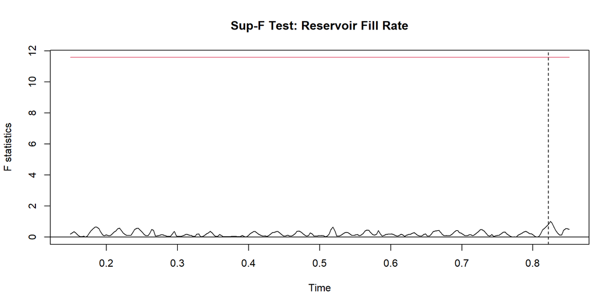

```r
plot(qlr_fill, main = "Sup-F Test: Reservoir Fill Rate")
lines(breakpoints(qlr_fill))
```

**Interpretation:** The Sup-F (QLR) test finds no evidence of a structural break in the reservoir fill rate series (sup.F = 1.0141, p = 1.00). As visible in the plot, the F-statistics computed at every candidate breakpoint across the full sample remain essentially flat and close to zero throughout, never approaching the 5% critical value shown by the red horizontal line (~11.7). The maximum F-statistic of just 1.0141 — with a p-value of 1 — means the null hypothesis of parameter stability cannot be rejected at any conventional significance level. The fill rate series has therefore maintained stable statistical properties across the entire 30-year sample, with no policy change, drought cycle, or climate shift producing a detectable permanent shift in its dynamics.

## 12.5 Joining Data

```r
# Join fill rate with hydro production and create lagged fill rate variable
reservoir_fill_rate <- hydro %>%
  inner_join(fill_rate_monthly, by = "Month") %>%
  arrange(Month) %>%
  mutate(
    fill_rate_pct = fill_rate_mean * 100,
    fill_rate_pct_lag1 = lag(fill_rate_pct, 1)
  ) %>%
  filter(!is.na(fill_rate_pct_lag1)) %>%
  as_tsibble(index = Month)

# Inspect
glimpse(reservoir_fill_rate)
```

```
## Rows: 374
## Columns: 10
## $ Month              <mth> 1995 Feb, 1995 Mar, 1995 Apr, 1995 May, 1995 Jun, 1…
## $ TWh                <dbl> 10.824208, 11.447300, 9.934022, 8.799962, 8.027187,…
## $ log_TWh            <dbl> 2.381785, 2.437754, 2.295965, 2.174747, 2.082834, 2…
## $ diff_TWh           <dbl> -1.342357, 0.623092, -1.513278, -1.134060, -0.77277…
## $ sdiff_TWh          <dbl> -0.545608, 1.315486, 1.675705, 0.654748, -0.240254,…
## $ fill_rate_mean     <dbl> 0.4419164, 0.3345651, 0.2420376, 0.2616069, 0.58768…
## $ energy_TWh_mean    <dbl> 38.64010, 29.25356, 21.16318, 22.87428, 51.38541, 6…
## $ capacity_TWh       <dbl> 87.43758, 87.43758, 87.43758, 87.43758, 87.43758, 8…
## $ fill_rate_pct      <dbl> 44.19164, 33.45651, 24.20376, 26.16069, 58.76811, 7…
## $ fill_rate_pct_lag1 <dbl> 55.88105, 44.19164, 33.45651, 24.20376, 26.16069, 5…
```

```r
reservoir_fill_rate %>% has_gaps()
```

```
## # A tibble: 1 × 1
##   .gaps
##   <lgl>
## 1 FALSE
```

```r
reservoir_fill_rate %>% scan_gaps()
```

```
## # A tsibble: 0 x 1 [?]
## # ℹ 1 variable: Month <mth>
```